# The ‘odemodeling’ R package

Juho Timonen

21 Feb 2022

This vignette demonstrates core functionality of the package.

```r
library(odemodeling)
```

```r
library(ggplot2)
```

# Creating a model

```r
sho_fun_body <- "
  vector[2] dy_dt;
  dy_dt[1] = y[2];
  dy_dt[2] = - y[1] - k*y[2];
  return(dy_dt);
"
```

We need to define the variable for the initial system state at `t0` as `y0`. The ODE system dimension is declared as `D` and number of time points as `N`.

```r
N <- stan_dim("N", lower=1)
D <- stan_dim("D")
y0 <- stan_vector("y0", length = D)
k <- stan_param(stan_var("k", lower=0), "inv_gamma(5, 1)")
```

Finally we declare the parameter `k` and its prior.

```r
k <- stan_param(stan_var("k", lower=0), prior = "inv_gamma(5, 1)")
```

The following code creates and compiles the Stan model.

```r
sho <- ode_model(N,
                 odefun_vars = list(k),
                 odefun_body = sho_fun_body,
                 odefun_init = y0)
print(sho)
```

```
#> An object of class OdeModel.
#>  * ODE dimension: int D;
#>  * Time points array dimension: int<lower=1> N;
#>  * Number of significant figures in csv files: 18
#>  * Has likelihood: FALSE
```

As we see, all variables that affect the function $f_{\psi}$ need to be given as the `odefun_vars` argument. The function body itself is then the `odefun_body` argument. In this function body, we can use the following variables without having to declare them or write Stan code that computes them:

- The ODE state `y`, which is a vector of same length as dimension of `y0`.
- Any variables that we give as `odefun_vars` for `ode_model`.
- Any variables that are dimensions of `odefun_vars`.

The initial state needs to be given as `odefun_init`. See the documentation of the `ode_model` function for more information.

We could call `print(sho$stanmodel)` to see the entire generated Stan model code.

# Sampling from prior

We can sample from the prior distribution of model parameters like so.

```r
sho_fit_prior <- sho$sample(
  t0 = 0.0,
  t = seq(0.1, 10, by = 0.1),
  data = list(y0 = c(1, 0), D = 2),
  refresh = 0,
  solver = rk45(
    abs_tol = 1e-13,
    rel_tol = 1e-13,
    max_num_steps = 1e9
  )
)
```

```
#> Running MCMC with 4 sequential chains...
#>
#> Chain 1 finished in 0.8 seconds.
#> Chain 2 finished in 0.7 seconds.
#> Chain 3 finished in 0.7 seconds.
#> Chain 4 finished in 0.7 seconds.
#>
#> All 4 chains finished successfully.
#> Mean chain execution time: 0.8 seconds.
#> Total execution time: 3.5 seconds.
```

We can view a summary of results

```r
print(sho_fit_prior)
```

```
#> An object of class OdeModelMCMC.
#>  * Number of chains: 4
#>  * Number of iterations: 1000
#>  * Total time: 3.488 seconds.
#>  * Used solver: rk45(abs_tol=1e-13, rel_tol=1e-13, max_num_steps=1e+09)
```

We can obtain the ODE solution using each parameter draw by doing

```r
ys <- sho_fit_prior$extract_odesol_df()
```

We can plot ODE solutions like so

```
#> Randomly selecting a subset of 100 draws to plot. Set draw_inds=0 to plot all 4000 draws.
```

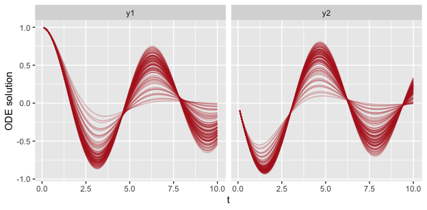

```r
sho_fit_prior$plot_odesol(alpha = 0.3)
```

We can plot the distribution of ODE solutions like so

```
#> plotting medians and 80% central intervals
```

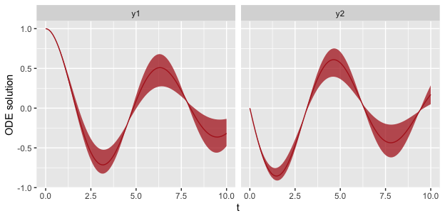

```r
sho_fit_prior$plot_odesol_dist(include_y0 = TRUE)
```

We can plot ODE solution using one draw like so

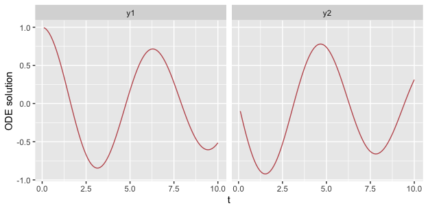

```r
sho_fit_prior$plot_odesol(draw_inds = 45)
```

# Using different ODE solvers

We generate quantities using a different `solver` and different output time points `t`. Possible solvers are `rk45()`,`bdf()`, `adams()`, `ckrk()`, `midpoint()`, and `rk4()`. Of these the first four are adaptive and built-in to Stan, where as the last two take a fixed number of steps and are written in Stan code.

```r
gq_bdf <- sho_fit_prior$gqs(solver = bdf(tol=1e-4), t = seq(0.5, 10, by = 0.5))
```

```
#> Running standalone generated quantities after 4 MCMC chains, 1 chain at a time ...
#>
#> Chain 1 finished in 0.0 seconds.
#> Chain 2 finished in 0.0 seconds.
#> Chain 3 finished in 0.0 seconds.
#> Chain 4 finished in 0.0 seconds.
#>
#> All 4 chains finished successfully.
#> Mean chain execution time: 0.0 seconds.
#> Total execution time: 0.5 seconds.
```

```r
gq_mp <- sho_fit_prior$gqs(solver = midpoint(num_steps=4), t = seq(0.5, 10, by = 0.5))
```

```
#> Running standalone generated quantities after 4 MCMC chains, 1 chain at a time ...
#>
#> Chain 1 finished in 0.0 seconds.
#> Chain 2 finished in 0.0 seconds.
#> Chain 3 finished in 0.0 seconds.
#> Chain 4 finished in 0.0 seconds.
#>
#> All 4 chains finished successfully.
#> Mean chain execution time: 0.0 seconds.
#> Total execution time: 0.5 seconds.
```

We can again plot ODE solution using one draw like so

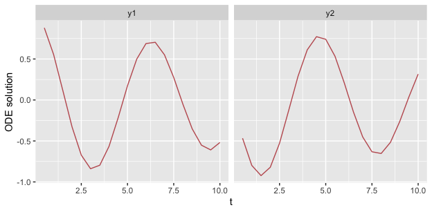

```r
gq_bdf$plot_odesol(draw_inds = 45)
```

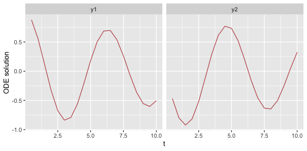

```r
gq_mp$plot_odesol(draw_inds = 45)
```

# Defining a likelihood

Next we assume that we have some data vector `y1_obs` and define a likelihood function.

```r
sho_loglik_body <- "
  real loglik = 0.0;
  for(n in 1:N) {
    loglik += normal_lpdf(y1_obs[n] | y_sol[n][1], sigma);
  }
  return(loglik);
"
```

In this function body, we can use the following variables without having to declare them or write Stan code that computes them:

- The ODE solution `y_sol`.
- Any variables that we give as `loglik_vars` for `ode_model`.
- Any variables that are dimensions of `loglik_vars`.

Here we define as `loglik_vars` a `sigma` which is a noise magnitude parameter, and the data `y1_obs`. Notice that we can also use the `N` variable in `loglik_body`, because it is a dimension (length) of `y1_obs`.

```r
sigma <- stan_param(stan_var("sigma", lower=0), prior="normal(0, 2)")
y1_obs <- stan_vector("y1_obs", length=N)
```

The following code creates and compiles the posterior Stan model.

```r
sho_post <- ode_model(N,
                 odefun_vars = list(k),
                 odefun_body = sho_fun_body,
                 odefun_init = y0,
                 loglik_vars = list(sigma, y1_obs),
                 loglik_body = sho_loglik_body)
print(sho_post)
```

```
#> An object of class OdeModel.
#>  * ODE dimension: int D;
#>  * Time points array dimension: int<lower=1> N;
#>  * Number of significant figures in csv files: 18
#>  * Has likelihood: TRUE
```

# Sampling from posterior

Now if we have some data

```r
y1_obs <- c(0.801, 0.391, 0.321, -0.826, -0.234, -0.663, -0.756, -0.717,
-0.078, -0.083,  0.988, 0.878, 0.300, 0.307, 0.270, -0.464, -0.403,
-0.295, -0.186, 0.158)
t_obs <- seq(0.5, 10, by = 0.5)
```

and assume that initial state `y0 = c(1, 0)` is known, we can fit the model

```r
sho_fit_post <- sho_post$sample(
  t0 = 0.0,
  t = t_obs,
  data = list(y0 = c(1, 0), D = 2, y1_obs = y1_obs),
  refresh = 0,
  solver = midpoint(2)
)
```

[output not shown]

[output cut: 20 more lines]

We fit the posterior distribution of ODE solutions against the data

```r
plt <- sho_fit_post$plot_odesol_dist()
```

```
#> plotting medians and 80% central intervals
```

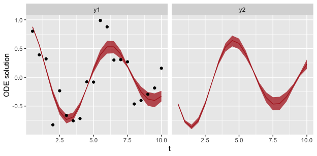

```r
df_data <- data.frame(t_obs, y1_obs, ydim=rep("y1", length(t_obs)))
colnames(df_data) <- c("t", "y", "ydim")
df_data$ydim <- as.factor(df_data$ydim)
plt <- plt + geom_point(data=df_data, aes(x=t,y=y), inherit.aes=FALSE)
plt
```

# Reliability of ODE solver

Finally we can study whether the solver we used during MCMC (`midpoint(2)`) was accurate enough. This is done by solving the system using increasingly more numbers of steps in the solver, and studying different metrics computed using the ODE solutions and corresponding likelihood values.

```r
solvers <- midpoint_list(c(4,6,8,10,12,14,16,18))
rel <- sho_fit_post$reliability(solvers = solvers)
```

[output not shown]

[output cut: 61 more lines]

[output not shown]

```r
print(rel$metrics)
```

```
#>    pareto_k    n_eff     r_eff mad_loglik mad_odesol
#> 1 0.1176621 2568.697 0.6551239   1.151924 0.05033225
#> 2 0.1163435 2516.645 0.6481001   1.383171 0.05954904
#> 3 0.1191357 2496.489 0.6455019   1.465447 0.06276090
#> 4 0.1168255 2486.756 0.6442629   1.503758 0.06424357
#> 5 0.1184567 2481.337 0.6435767   1.524628 0.06504748
#> 6 0.1155186 2478.024 0.6431573   1.537231 0.06553156
#> 7 0.1143430 2475.851 0.6428822   1.545418 0.06584543
#> 8 0.1130321 2474.350 0.6426921   1.551034 0.06606043
```

```r
unlink("results")
```

The `mad_odesol` and `mad_loglik` are the maximum absolute difference in the ODE solutions and log likelihood, respectively, over all MCMC draws. The former is denoted *MAE* in *Timonen et. al (2022)*. Please refer to that paper in order to interpret the `pareto_k` column. Briefly we note that the Pareto-k values seem to be converging to a value smaller than 0.5, meaning that importance sampling is possible and we don’t need to run MCMC again.

# References

- Timonen et. al (2022). *An importance sampling approach for reliable and efficient inference in Bayesian ordinary differential equation models*. [arXiv](https://arxiv.org/abs/2205.09059)